# competicion titanic kaggle

Alberto Mengual

7/28/2021

Por una parte tendré que hacer el **estudio descriptivo** del dataset y por otro crear el **modelo de clasificación.**

##### ¿Cual es el objetivo del analisis descriptivo?

Entender los datos antes de crear el modelo

Estoy observando que hay varias variables que no me hacen falta para el analisis descriptivo:

- el nombre
- el numero de ticket
- la cabina - cubierta
- la tarifa casi que la debería borrar

Estaría bien cambiarle el nombre a las variables y traducirlas

Creo que podría crear una columna que se llame familiares y sea la suma de las otras dos. - las dejo tal cual

Tambien se podría trabajar con las **cubiertas** (para analizar en que cubiertas se salvaron más hombres?)

He agrupado las edades. Estaría bien crear tablas agrupadas de variables cualitativas:

- supervivientes, genero, clase - HECHO
- supervivientes, genero, familiares

¿Dónde se estudian las matrices de correlación?

Se puede hacer un histograma agrupado??

##### ¿Cuales son los pasos?¿Cuantas veces tengo que importar el dataset?

Eliminar las variables que no son interesantes.

Distinguir las variables cualitativas, ordinales y cuantitativas. Crear factores y factores ordenados.

Hacer el analisis descriptivo: cualitativas, ordinales, cuantitativas, agrupadas, histograma.

¿Que hago con los NA de las edades? ¿Los sustituyo por la media? ¿cuando? ¿antes de hacer los histogramas? quizas se podria hacer la copia de df y el tratamiento de los na antes de hacer el histograma.

##### ¿Que tengo que considerar al crear el modelo de clasificación?

Quiero crear varios modelos y compararlos

Codificar como factor la variable de clasificación - HECHO

¿Hay que separarla del conjunto?? No, en principio, porque ya lo tengo separado. Lo que tendría que hacer es aplicar los cambios en las variables al conjunto de test.

### IMPORTAR DATASETS

Importar el data frame de la competición, en este caso el de titanic. Los conjuntos de entrenamiento y de test.

```r
train = read.csv("../datasets/train.csv", row.names = 1)
test = read.csv("../datasets/test.csv")


# Eliminar las columnas innecesarias del data frame
df = train[,c(-3,-8,-10)]

# Renombrar variables
names(df) = c("Superviviente", "clase", "genero", "edad", "SibSp", "Parch", "Tarifa", "Puerto")

# Codificar como factor la variable de clasificación
df$Superviviente = factor(df$Superviviente, levels = c(0,1))


# convertir las variables categoricas a factores:
df$genero = factor(df$genero, labels = c("mujer","hombre"))
df$clase = factor(df$clase, levels = c(3,2,1), ordered = TRUE)
df$SibSp = factor(df$SibSp, ordered = TRUE)
df$Parch = factor(df$Parch, ordered = TRUE)

# convertir las variables categoricas a factores en el cojunto de test:
test$Sex = factor(test$Sex, labels = c(1,2))
test$Pclass = factor(test$Pclass, levels = c(3,2,1), ordered = TRUE)
test$SibSp = factor(test$SibSp, ordered = TRUE)
test$Parch = factor(test$Parch, ordered = TRUE)
```

### INFORMACIÓN BÁSICA DEL DATASET Y CREACION DE FACTORES

```r
head(df)
```

```
##   Superviviente clase genero edad SibSp Parch  Tarifa Puerto
## 1             0     3 hombre   22     1     0  7.2500      S
## 2             1     1  mujer   38     1     0 71.2833      C
## 3             1     3  mujer   26     0     0  7.9250      S
## 4             1     1  mujer   35     1     0 53.1000      S
## 5             0     3 hombre   35     0     0  8.0500      S
## 6             0     3 hombre   NA     0     0  8.4583      Q
```

```r
str(df)
```

```
## 'data.frame':    891 obs. of  8 variables:
##  $ Superviviente: Factor w/ 2 levels "0","1": 1 2 2 2 1 1 1 1 2 2 ...
##  $ clase        : Ord.factor w/ 3 levels "3"<"2"<"1": 1 3 1 3 1 1 3 1 1 2 ...
##  $ genero       : Factor w/ 2 levels "mujer","hombre": 2 1 1 1 2 2 2 2 1 1 ...
##  $ edad         : num  22 38 26 35 35 NA 54 2 27 14 ...
##  $ SibSp        : Ord.factor w/ 7 levels "0"<"1"<"2"<"3"<..: 2 2 1 2 1 1 1 4 1 2 ...
##  $ Parch        : Ord.factor w/ 7 levels "0"<"1"<"2"<"3"<..: 1 1 1 1 1 1 1 2 3 1 ...
##  $ Tarifa       : num  7.25 71.28 7.92 53.1 8.05 ...
##  $ Puerto       : Factor w/ 4 levels "","C","Q","S": 4 2 4 4 4 3 4 4 4 2 ...
```

```r
summary(df)
```

```
##  Superviviente clase      genero         edad       SibSp   Parch
##  0:549         3:491   mujer :314   Min.   : 0.42   0:608   0:678
##  1:342         2:184   hombre:577   1st Qu.:20.12   1:209   1:118
##                1:216                Median :28.00   2: 28   2: 80
##                                     Mean   :29.70   3: 16   3:  5
##                                     3rd Qu.:38.00   4: 18   4:  4
##                                     Max.   :80.00   5:  5   5:  5
##                                     NA's   :177     8:  7   6:  1
##      Tarifa       Puerto
##  Min.   :  0.00    :  2
##  1st Qu.:  7.91   C:168
##  Median : 14.45   Q: 77
##  Mean   : 32.20   S:644
##  3rd Qu.: 31.00
##  Max.   :512.33
##
```

### Variables cualitativas y ordinales * Diagramas de mosaico

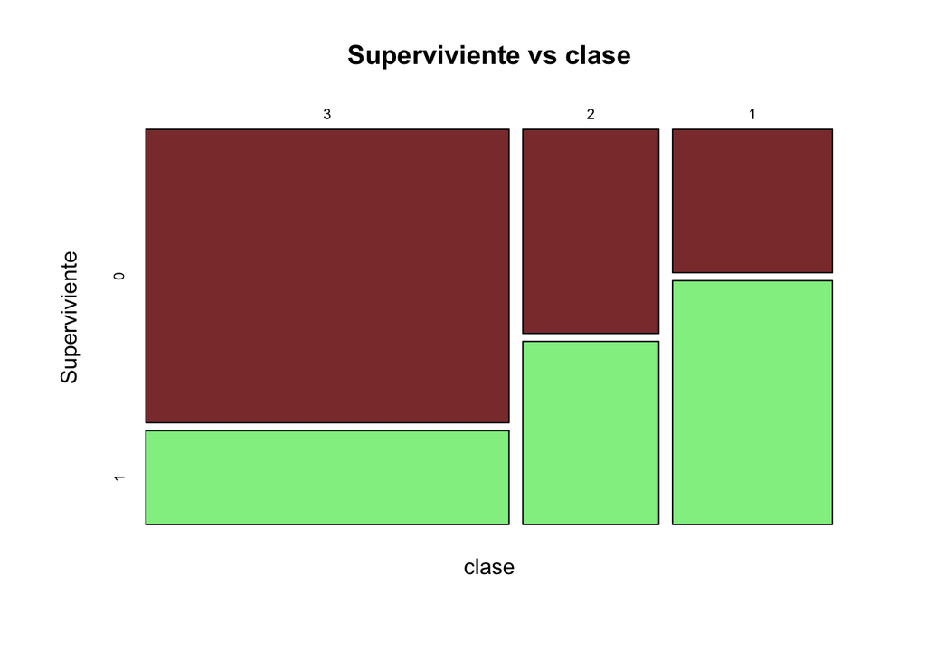

```
##
##    Cell Contents
## |-------------------------|
## |                   Count |
## |             Row Percent |
## |          Column Percent |
## |           Total Percent |
## |-------------------------|
##
## Total Observations in Table:  891
##
##              | Superviviente
##        clase |        0  |        1  | Row Total |
## -------------|-----------|-----------|-----------|
##            3 |      372  |      119  |      491  |
##              |   75.764% |   24.236% |   55.107% |
##              |   67.760% |   34.795% |           |
##              |   41.751% |   13.356% |           |
## -------------|-----------|-----------|-----------|
##            2 |       97  |       87  |      184  |
##              |   52.717% |   47.283% |   20.651% |
##              |   17.668% |   25.439% |           |
##              |   10.887% |    9.764% |           |
## -------------|-----------|-----------|-----------|
##            1 |       80  |      136  |      216  |
##              |   37.037% |   62.963% |   24.242% |
##              |   14.572% |   39.766% |           |
##              |    8.979% |   15.264% |           |
## -------------|-----------|-----------|-----------|
## Column Total |      549  |      342  |      891  |
##              |   61.616% |   38.384% |           |
## -------------|-----------|-----------|-----------|
##
##
```

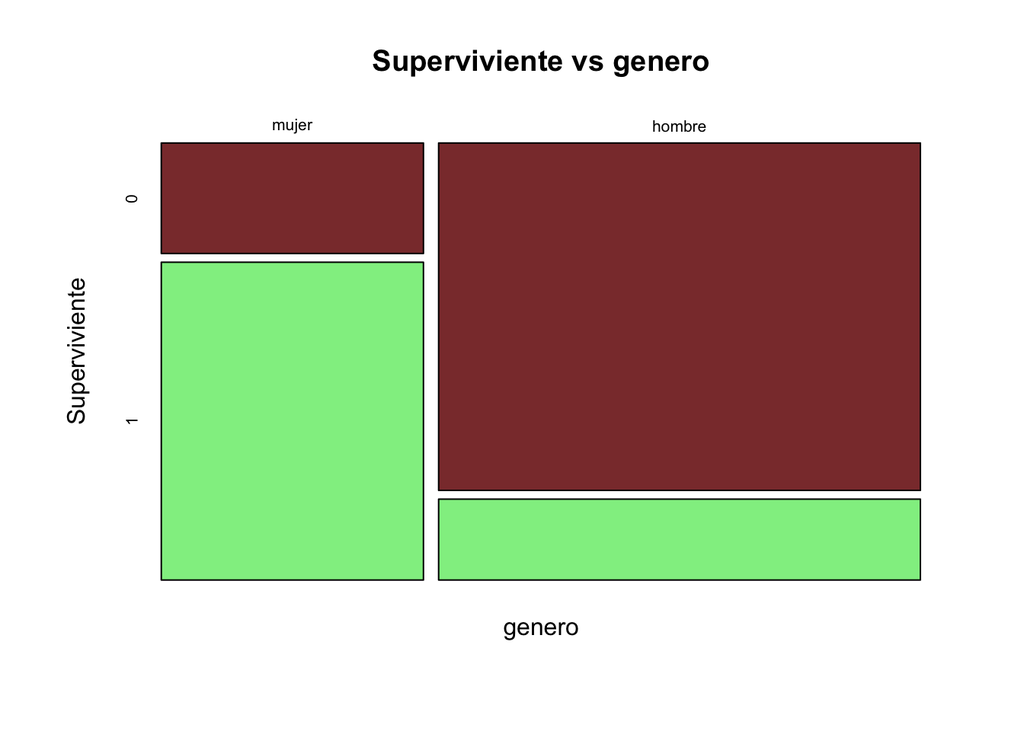

```
##
##    Cell Contents
## |-------------------------|
## |                   Count |
## |             Row Percent |
## |          Column Percent |
## |           Total Percent |
## |-------------------------|
##
## Total Observations in Table:  891
##
##              | Superviviente
##       genero |        0  |        1  | Row Total |
## -------------|-----------|-----------|-----------|
##        mujer |       81  |      233  |      314  |
##              |   25.796% |   74.204% |   35.241% |
##              |   14.754% |   68.129% |           |
##              |    9.091% |   26.150% |           |
## -------------|-----------|-----------|-----------|
##       hombre |      468  |      109  |      577  |
##              |   81.109% |   18.891% |   64.759% |
##              |   85.246% |   31.871% |           |
##              |   52.525% |   12.233% |           |
## -------------|-----------|-----------|-----------|
## Column Total |      549  |      342  |      891  |
##              |   61.616% |   38.384% |           |
## -------------|-----------|-----------|-----------|
##
##
```

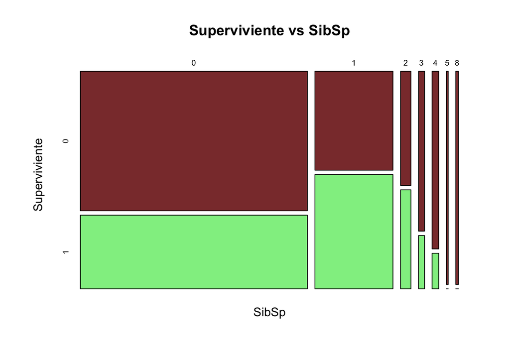

```
##
##    Cell Contents
## |-------------------------|
## |                   Count |
## |             Row Percent |
## |          Column Percent |
## |           Total Percent |
## |-------------------------|
##
## Total Observations in Table:  891
##
##              | Superviviente
##        SibSp |        0  |        1  | Row Total |
## -------------|-----------|-----------|-----------|
##            0 |      398  |      210  |      608  |
##              |   65.461% |   34.539% |   68.238% |
##              |   72.495% |   61.404% |           |
##              |   44.669% |   23.569% |           |
## -------------|-----------|-----------|-----------|
##            1 |       97  |      112  |      209  |
##              |   46.411% |   53.589% |   23.457% |
##              |   17.668% |   32.749% |           |
##              |   10.887% |   12.570% |           |
## -------------|-----------|-----------|-----------|
##            2 |       15  |       13  |       28  |
##              |   53.571% |   46.429% |    3.143% |
##              |    2.732% |    3.801% |           |
##              |    1.684% |    1.459% |           |
## -------------|-----------|-----------|-----------|
##            3 |       12  |        4  |       16  |
##              |   75.000% |   25.000% |    1.796% |
##              |    2.186% |    1.170% |           |
##              |    1.347% |    0.449% |           |
## -------------|-----------|-----------|-----------|
##            4 |       15  |        3  |       18  |
##              |   83.333% |   16.667% |    2.020% |
##              |    2.732% |    0.877% |           |
##              |    1.684% |    0.337% |           |
## -------------|-----------|-----------|-----------|
##            5 |        5  |        0  |        5  |
##              |  100.000% |    0.000% |    0.561% |
##              |    0.911% |    0.000% |           |
##              |    0.561% |    0.000% |           |
## -------------|-----------|-----------|-----------|
##            8 |        7  |        0  |        7  |
##              |  100.000% |    0.000% |    0.786% |
##              |    1.275% |    0.000% |           |
##              |    0.786% |    0.000% |           |
## -------------|-----------|-----------|-----------|
## Column Total |      549  |      342  |      891  |
##              |   61.616% |   38.384% |           |
## -------------|-----------|-----------|-----------|
##
##
```

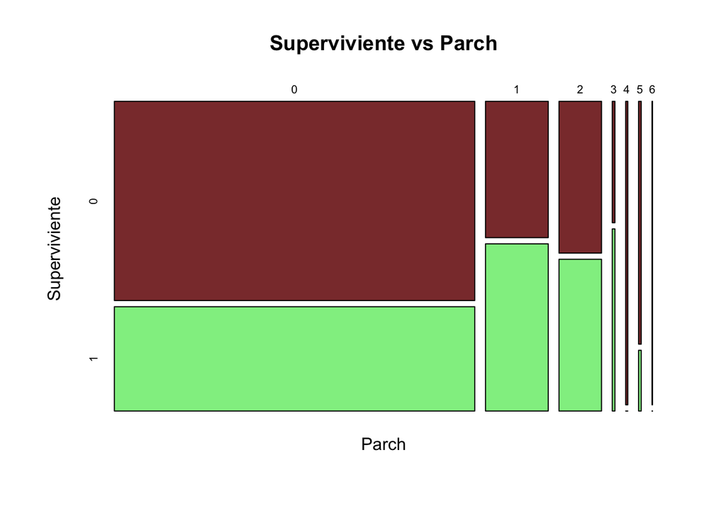

```
##
##    Cell Contents
## |-------------------------|
## |                   Count |
## |             Row Percent |
## |          Column Percent |
## |           Total Percent |
## |-------------------------|
##
## Total Observations in Table:  891
##
##              | Superviviente
##        Parch |        0  |        1  | Row Total |
## -------------|-----------|-----------|-----------|
##            0 |      445  |      233  |      678  |
##              |   65.634% |   34.366% |   76.094% |
##              |   81.056% |   68.129% |           |
##              |   49.944% |   26.150% |           |
## -------------|-----------|-----------|-----------|
##            1 |       53  |       65  |      118  |
##              |   44.915% |   55.085% |   13.244% |
##              |    9.654% |   19.006% |           |
##              |    5.948% |    7.295% |           |
## -------------|-----------|-----------|-----------|
##            2 |       40  |       40  |       80  |
##              |   50.000% |   50.000% |    8.979% |
##              |    7.286% |   11.696% |           |
##              |    4.489% |    4.489% |           |
## -------------|-----------|-----------|-----------|
##            3 |        2  |        3  |        5  |
##              |   40.000% |   60.000% |    0.561% |
##              |    0.364% |    0.877% |           |
##              |    0.224% |    0.337% |           |
## -------------|-----------|-----------|-----------|
##            4 |        4  |        0  |        4  |
##              |  100.000% |    0.000% |    0.449% |
##              |    0.729% |    0.000% |           |
##              |    0.449% |    0.000% |           |
## -------------|-----------|-----------|-----------|
##            5 |        4  |        1  |        5  |
##              |   80.000% |   20.000% |    0.561% |
##              |    0.729% |    0.292% |           |
##              |    0.449% |    0.112% |           |
## -------------|-----------|-----------|-----------|
##            6 |        1  |        0  |        1  |
##              |  100.000% |    0.000% |    0.112% |
##              |    0.182% |    0.000% |           |
##              |    0.112% |    0.000% |           |
## -------------|-----------|-----------|-----------|
## Column Total |      549  |      342  |      891  |
##              |   61.616% |   38.384% |           |
## -------------|-----------|-----------|-----------|
##
##
```

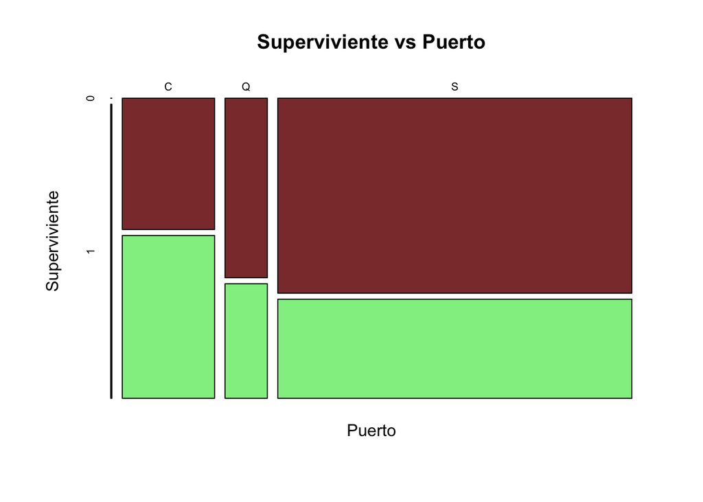

```
##
##    Cell Contents
## |-------------------------|
## |                   Count |
## |             Row Percent |
## |          Column Percent |
## |           Total Percent |
## |-------------------------|
##
## Total Observations in Table:  891
##
##              | Superviviente
##       Puerto |        0  |        1  | Row Total |
## -------------|-----------|-----------|-----------|
##              |        0  |        2  |        2  |
##              |    0.000% |  100.000% |    0.224% |
##              |    0.000% |    0.585% |           |
##              |    0.000% |    0.224% |           |
## -------------|-----------|-----------|-----------|
##            C |       75  |       93  |      168  |
##              |   44.643% |   55.357% |   18.855% |
##              |   13.661% |   27.193% |           |
##              |    8.418% |   10.438% |           |
## -------------|-----------|-----------|-----------|
##            Q |       47  |       30  |       77  |
##              |   61.039% |   38.961% |    8.642% |
##              |    8.561% |    8.772% |           |
##              |    5.275% |    3.367% |           |
## -------------|-----------|-----------|-----------|
##            S |      427  |      217  |      644  |
##              |   66.304% |   33.696% |   72.278% |
##              |   77.778% |   63.450% |           |
##              |   47.924% |   24.355% |           |
## -------------|-----------|-----------|-----------|
## Column Total |      549  |      342  |      891  |
##              |   61.616% |   38.384% |           |
## -------------|-----------|-----------|-----------|
##
##
```

```r
cual.col = c()
for (i in names(df)) {
  if ("factor" %in% class(df[,i])){
    cual.col = c(cual.col,i)
  }
}
library(gmodels)

for (i in cual.col) {
  if (i != "Superviviente" & i!="div1") {
    plot(table(df[,i],df[,"Superviviente"]), xlab = i, ylab = "Superviviente",
         main = paste("Superviviente vs",i), col = c("indianred4","lightgreen"))

    CrossTable(df[,i],df[,"Superviviente"], prop.chisq = FALSE, dnn = c(i,"Superviviente"),
               format = "SPSS")
  }
}
```

#### TABLAS MULTIDIMENSIONALES

```r
ftable(df$genero, df$clase, df$Superviviente)
```

```
##             0   1
##
## mujer  3   72  72
##        2    6  70
##        1    3  91
## hombre 3  300  47
##        2   91  17
##        1   77  45
```

```r
ftable(100*round(prop.table(table(df$genero, df$clase, df$Superviviente)),3))
```

```
##              0    1
##
## mujer  3   8.1  8.1
##        2   0.7  7.9
##        1   0.3 10.2
## hombre 3  33.7  5.3
##        2  10.2  1.9
##        1   8.6  5.1
```

### CONCLUSIONES DEL ANALISIS DESCRIPTIVO CUALITATIVO

En relación a la clase, las personas de primera clase son las que más posibilidades tuvieron de sobrevivir. Aunque sobrevivieron más personas de tercera clase, que de segunda, en proporcion las de tercera eran las que menos probabilidades tuvieron de sobrevivir.

La mayoría de los supervivientes fueron mujeres un 68% del total de supervivientes. Se rescató a un 75% del total de las mujeres del barco. ¿Que porcentaje de mujeres de primera clase se rescato?

La mayoría de los supervivientes viajaban sin pareja o hermanos. El hecho de tener uno o dos hermanos o una pareja aumentó las probabilidades de supervivencia.

La mayoría de los supervivientes viajo sin padres o hijos. Viajar con los padres o con hasta 3 hijos aumentó las probabilidades de supervivencia.

La mayoría de los supervivientes embarcarón en Southampton. Embarcar en cualquiera de los otros dos puertos aumentó las probabilidades de supervivencia siendo los de Cherbourg los que salieron mejor parados.

### VARIABLES CUANTITATIVAS: LA EDAD

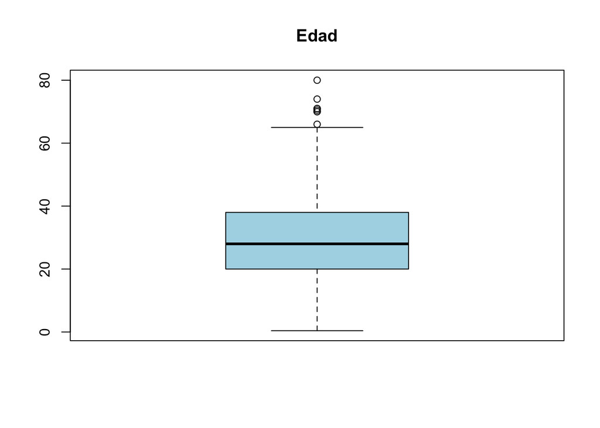

```r
boxplot(df$edad, col = "lightblue", notch = FALSE, main = "Edad")
points(mean(df$edad), col = "gold", pch=19, cex = 1.5)
```

```r
summC = summary(df$edad)
print("Tabla Resumen de Edad")
```

```
## [1] "Tabla Resumen de Edad"
```

```r
print(summC)
```

```
##    Min. 1st Qu.  Median    Mean 3rd Qu.    Max.    NA's
##    0.42   20.12   28.00   29.70   38.00   80.00     177
```

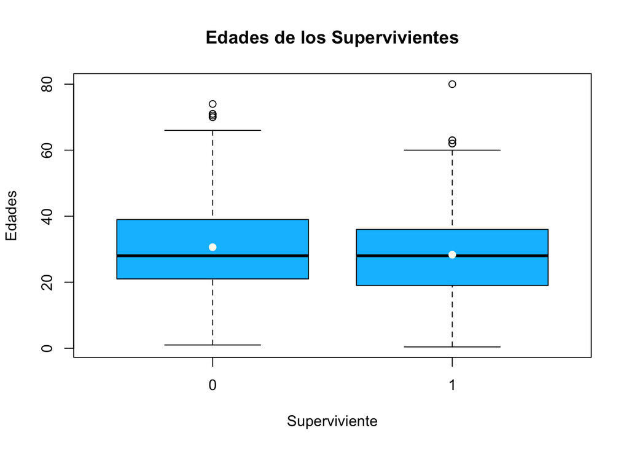

```r
boxplot(df$edad~df$Superviviente, col = "deepskyblue",
            main = "Edades de los Supervivientes",
            ylab = "Edades", xlab = "Superviviente")
medias = aggregate(df$edad~df$Superviviente, FUN = mean)
points(medias, col = "floralwhite", pch = 19)
```

```r
tSum = by(df$edad,df$Superviviente, FUN = summary)
print(tSum)
```

```
## df$Superviviente: 0
##    Min. 1st Qu.  Median    Mean 3rd Qu.    Max.    NA's
##    1.00   21.00   28.00   30.63   39.00   74.00     125
## ------------------------------------------------------------
## df$Superviviente: 1
##    Min. 1st Qu.  Median    Mean 3rd Qu.    Max.    NA's
##    0.42   19.00   28.00   28.34   36.00   80.00      52
```

```r
e = df$edad
# em = df$edad[df$genero == "mujer"]
# eh = df$edad[,df$genero=="hombre"]
n= length(e)
k1 = ceiling(sqrt(n))
print(k1)
```

```
## [1] 30
```

```r
k2 = ceiling(1+log(n,2))
print(k2)
```

```
## [1] 11
```

```r
As = 3.5*sd(e)*n^(-1/3)
k3 = ceiling(diff(range(e))/As)
print(k3)
```

```
## [1] NA
```

```r
Afd = 2*(quantile(e,0.75,names = FALSE, na.rm = TRUE)-quantile(e,0.25,names = FALSE, na.rm = TRUE))*n^(-1/3)
k4 = ceiling(diff(range(e))/Afd)
print(k4)
```

```
## [1] NA
```

```r
k5 = nclass.Sturges(e)
print(k5)
```

```
## [1] 11
```

```r
#k6 = nclass.scott(e)
#print(k6)

#k7 = nclass.FD(e)
#print(k7)
```

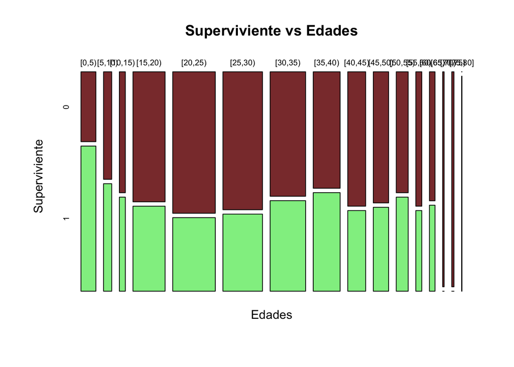

```r
L = seq(0,80,5)
df$div1 = cut(e, breaks = L, right = FALSE, include.lowest = TRUE)
plot(table(df$div1,df[,"Superviviente"]), xlab = "Edades", ylab = "Superviviente",
         main = "Superviviente vs Edades", col = c("indianred4","lightgreen"))
```

```r
CrossTable(df$div1,df[,"Superviviente"], prop.chisq = FALSE,
               dnn = c("Edades","Superviviente"),format = "SPSS")
```

```
##
##    Cell Contents
## |-------------------------|
## |                   Count |
## |             Row Percent |
## |          Column Percent |
## |           Total Percent |
## |-------------------------|
##
## Total Observations in Table:  714
##
##              | Superviviente
##       Edades |        0  |        1  | Row Total |
## -------------|-----------|-----------|-----------|
##        [0,5) |       13  |       27  |       40  |
##              |   32.500% |   67.500% |    5.602% |
##              |    3.066% |    9.310% |           |
##              |    1.821% |    3.782% |           |
## -------------|-----------|-----------|-----------|
##       [5,10) |       11  |       11  |       22  |
##              |   50.000% |   50.000% |    3.081% |
##              |    2.594% |    3.793% |           |
##              |    1.541% |    1.541% |           |
## -------------|-----------|-----------|-----------|
##      [10,15) |        9  |        7  |       16  |
##              |   56.250% |   43.750% |    2.241% |
##              |    2.123% |    2.414% |           |
##              |    1.261% |    0.980% |           |
## -------------|-----------|-----------|-----------|
##      [15,20) |       52  |       34  |       86  |
##              |   60.465% |   39.535% |   12.045% |
##              |   12.264% |   11.724% |           |
##              |    7.283% |    4.762% |           |
## -------------|-----------|-----------|-----------|
##      [20,25) |       75  |       39  |      114  |
##              |   65.789% |   34.211% |   15.966% |
##              |   17.689% |   13.448% |           |
##              |   10.504% |    5.462% |           |
## -------------|-----------|-----------|-----------|
##      [25,30) |       68  |       38  |      106  |
```

[output cut: 44 more lines]

```
##      [70,75) |        6  |        0  |        6  |
##              |  100.000% |    0.000% |    0.840% |
##              |    1.415% |    0.000% |           |
##              |    0.840% |    0.000% |           |
## -------------|-----------|-----------|-----------|
##      [75,80] |        0  |        1  |        1  |
##              |    0.000% |  100.000% |    0.140% |
##              |    0.000% |    0.345% |           |
##              |    0.000% |    0.140% |           |
## -------------|-----------|-----------|-----------|
## Column Total |      424  |      290  |      714  |
##              |   59.384% |   40.616% |           |
## -------------|-----------|-----------|-----------|
##
##
```

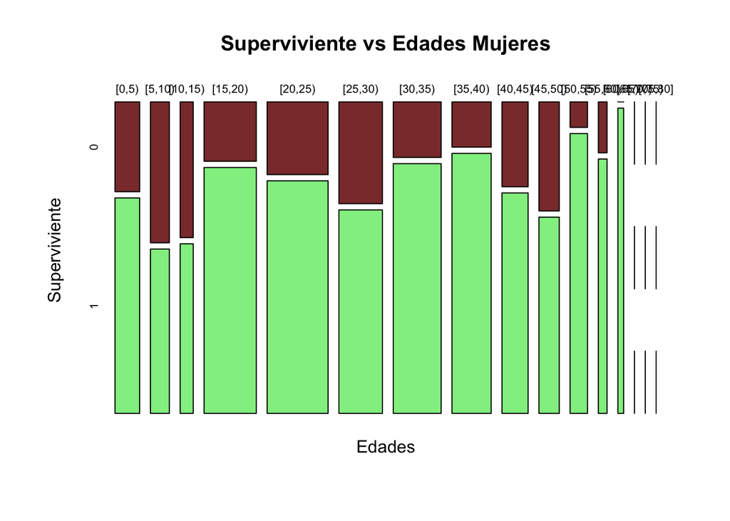

```r
plot(table(df$div1[df$genero=="mujer"],df$Superviviente[df$genero=="mujer"]), xlab = "Edades", ylab = "Superviviente",
         main = "Superviviente vs Edades Mujeres", col = c("indianred4","lightgreen"))
```

```r
CrossTable(df$div1[df$genero=="mujer"],df[,"Superviviente"][df$genero=="mujer"],
           prop.chisq = FALSE,
               dnn = c("Edades","Superviviente"),format = "SPSS")
```

```
##
##    Cell Contents
## |-------------------------|
## |                   Count |
## |             Row Percent |
## |          Column Percent |
## |           Total Percent |
## |-------------------------|
##
## Total Observations in Table:  261
##
##              | Superviviente
##       Edades |        0  |        1  | Row Total |
## -------------|-----------|-----------|-----------|
##        [0,5) |        5  |       12  |       17  |
##              |   29.412% |   70.588% |    6.513% |
##              |    7.812% |    6.091% |           |
##              |    1.916% |    4.598% |           |
## -------------|-----------|-----------|-----------|
##       [5,10) |        6  |        7  |       13  |
##              |   46.154% |   53.846% |    4.981% |
##              |    9.375% |    3.553% |           |
##              |    2.299% |    2.682% |           |
## -------------|-----------|-----------|-----------|
##      [10,15) |        4  |        5  |        9  |
##              |   44.444% |   55.556% |    3.448% |
##              |    6.250% |    2.538% |           |
##              |    1.533% |    1.916% |           |
## -------------|-----------|-----------|-----------|
##      [15,20) |        7  |       29  |       36  |
##              |   19.444% |   80.556% |   13.793% |
##              |   10.938% |   14.721% |           |
##              |    2.682% |   11.111% |           |
## -------------|-----------|-----------|-----------|
##      [20,25) |       10  |       32  |       42  |
##              |   23.810% |   76.190% |   16.092% |
##              |   15.625% |   16.244% |           |
##              |    3.831% |   12.261% |           |
## -------------|-----------|-----------|-----------|
##      [25,30) |       10  |       20  |       30  |
```

[output cut: 29 more lines]

```
##      [55,60) |        1  |        5  |        6  |
##              |   16.667% |   83.333% |    2.299% |
##              |    1.562% |    2.538% |           |
##              |    0.383% |    1.916% |           |
## -------------|-----------|-----------|-----------|
##      [60,65) |        0  |        4  |        4  |
##              |    0.000% |  100.000% |    1.533% |
##              |    0.000% |    2.030% |           |
##              |    0.000% |    1.533% |           |
## -------------|-----------|-----------|-----------|
## Column Total |       64  |      197  |      261  |
##              |   24.521% |   75.479% |           |
## -------------|-----------|-----------|-----------|
##
##
```

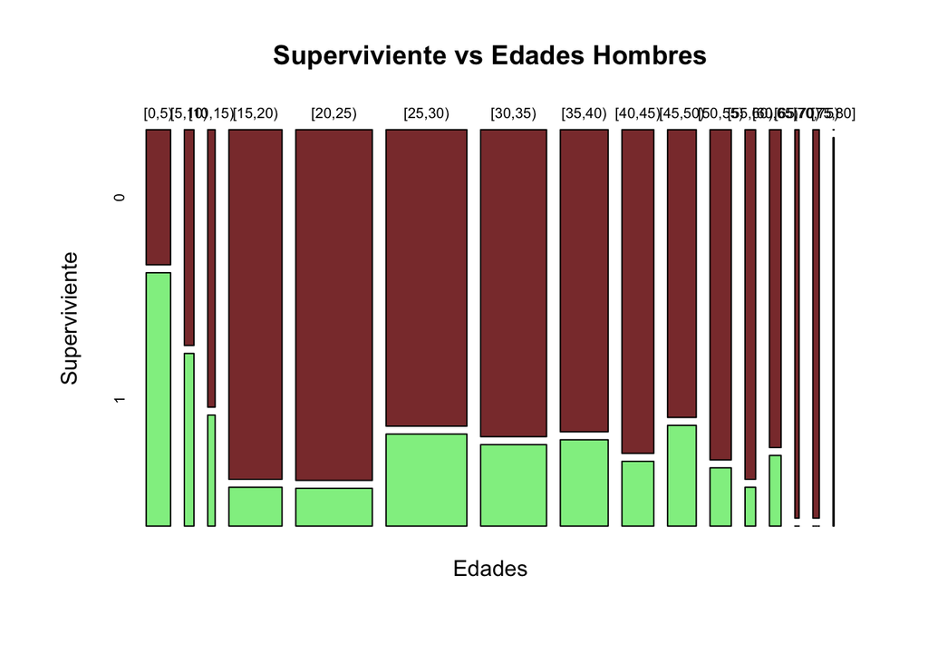

```r
plot(table(df$div1[df$genero=="hombre"],df[,"Superviviente"][df$genero=="hombre"]),
     xlab = "Edades", ylab = "Superviviente",
         main = "Superviviente vs Edades Hombres", col = c("indianred4","lightgreen"))
```

```r
CrossTable(df$div1[df$genero=="hombre"],df[,"Superviviente"][df$genero=="hombre"], prop.chisq = FALSE,
               dnn = c("Edades","Superviviente"),format = "SPSS")
```

```
##
##    Cell Contents
## |-------------------------|
## |                   Count |
## |             Row Percent |
## |          Column Percent |
## |           Total Percent |
## |-------------------------|
##
## Total Observations in Table:  453
##
##              | Superviviente
##       Edades |        0  |        1  | Row Total |
## -------------|-----------|-----------|-----------|
##        [0,5) |        8  |       15  |       23  |
##              |   34.783% |   65.217% |    5.077% |
##              |    2.222% |   16.129% |           |
##              |    1.766% |    3.311% |           |
## -------------|-----------|-----------|-----------|
##       [5,10) |        5  |        4  |        9  |
##              |   55.556% |   44.444% |    1.987% |
##              |    1.389% |    4.301% |           |
##              |    1.104% |    0.883% |           |
## -------------|-----------|-----------|-----------|
##      [10,15) |        5  |        2  |        7  |
##              |   71.429% |   28.571% |    1.545% |
##              |    1.389% |    2.151% |           |
##              |    1.104% |    0.442% |           |
## -------------|-----------|-----------|-----------|
##      [15,20) |       45  |        5  |       50  |
##              |   90.000% |   10.000% |   11.038% |
##              |   12.500% |    5.376% |           |
##              |    9.934% |    1.104% |           |
## -------------|-----------|-----------|-----------|
##      [20,25) |       65  |        7  |       72  |
##              |   90.278% |    9.722% |   15.894% |
##              |   18.056% |    7.527% |           |
##              |   14.349% |    1.545% |           |
## -------------|-----------|-----------|-----------|
##      [25,30) |       58  |       18  |       76  |
```

[output cut: 44 more lines]

```
##      [70,75) |        6  |        0  |        6  |
##              |  100.000% |    0.000% |    1.325% |
##              |    1.667% |    0.000% |           |
##              |    1.325% |    0.000% |           |
## -------------|-----------|-----------|-----------|
##      [75,80] |        0  |        1  |        1  |
##              |    0.000% |  100.000% |    0.221% |
##              |    0.000% |    1.075% |           |
##              |    0.000% |    0.221% |           |
## -------------|-----------|-----------|-----------|
## Column Total |      360  |       93  |      453  |
##              |   79.470% |   20.530% |           |
## -------------|-----------|-----------|-----------|
##
##
```

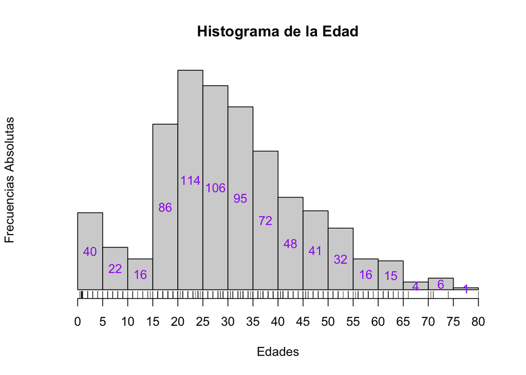

```r
L = seq(0,80,5)
h = hist(df$edad, breaks = L, right = FALSE,
         freq = FALSE,
     main = "Histograma de la Edad", xlab = "Edades", ylab = "Frecuencias Absolutas",
#     ylim = c(0,120),
     xaxt = "n",
     yaxt = "n",
      col = "lightgray")
axis(1, at=L)
text(h$mids, h$density/2, labels=h$counts, col="purple")
# lines(density(df$edad), col ="purple", lwd = 2)
rug(jitter(df$edad))
```

### CONCLUSIONES DEL ANALISIS DESCRIPTIVO CUALITATIVO

No parece que la edad hubiera sido un criterio significativo para seleccionar a los supervivientes. Excepto en el caso de los varones menores de 10 años que tuvieron una mayor probabilidad de supervivencia que el resto de los varones en general.

## CREACION DEL MODELO PREDICTIVO

### PREPROCESADO DE DATOS

Tratamiento de los NA

codificar las variables categoricas

dividir los datos en entrenamiento y test - Aunque parezca que esta hecho, no lo está. El conjunto de test actual es para enviar los resultados. Si quiero comprobar mi propia matriz de confusión tendré que hacer la división de los conjuntos de test y entrenamiento.

¿Se puede hacer el crossvalidation en R?

Me falta seleccionar las variables, crear copia de test

escalar los valores

crear modelo de clasificación

#### Tratamiento de los valores NA

Sustiruir los na de la variable edad por la media. Una alternativa sería crear edades **aleatorias.**

```r
dataset = df

df$edad = ifelse(is.na(df$edad),
                   ave(df$edad,FUN = function(x) mean(x,na.rm=T)),
                   df$edad)

# solucionar los NAs del conjunto de test
test$Age = ifelse(is.na(test$Age),
                   ave(test$Age,FUN = function(x) mean(x,na.rm=T)),
                   test$Age)
```

#### CODIFICAR LAS VARIABLES CATEGORICAS

Cambiar las etiquetas de la varible genero

```r
df$genero = factor(df$genero, labels = c(1,2))
df$Puerto = factor(df$Puerto, labels = c(1,2,3,4))

# Codificar factores del cojunto de test
test$Sex = factor(test$Sex, labels = c(1,2))
test$Embarked = factor(test$Embarked, labels = c(2,3,4))
```

#### DIVIDIR LOS DATOS EN ENTRENAMIENTO Y TEST - ELECCION DE VARIABLES

Voy a aplicar el K-fold Cross Validation así que no voy a dividir en entrenamiento y test todavía. Pero si voy a elegir las variables con las que voy a trabajar.

```r
# A df la voy a quitar la tarifa y las edades agrupadas
df2 = df[,c(-7,-9)]
# Al test le voy a quitar: PassengerId, Name, Ticket, Fare, Cabin
test2 = test[,c(-1,-3,-8,-9,-10)]
```